# Stat300 Group Project Part(1)-(3)

“Jiahao Li”

## (1):

We’ll split the dataset into a training set (72 observations) and a testing set (18 observations). Our group number is 10, so the seed will be 30010.

```r
ucars <- read.csv("usedcars.csv")

set.seed(30010)

trainRec <- sort(sample(1:nrow(ucars), size = 72))

testRec <- setdiff(1:nrow(ucars), trainRec)

traincars <- ucars[trainRec, ]
testcars <- ucars[testRec, ]
```

## (2):

Data Exploration Plan

We’ll perform:

- Summary statistics
- Check for missing or inconsistent values
- Graphical exploration of relationships

Key Points from Data

- **Categorical variables:** `Fuel_Type`, `Transmission`, `Owner_Type`
- **Numerical variables:** `Kilometers_Driven`, `Mileage`, `Engine`, `Power`, `Seats`, `Age (2025 - Year)`
- **Target variable:** `Price`

We will also add an `Age` variable.

```r
# Create Age column
traincars$Age <- 2025 - traincars$Year

# Summary statistics
summary(traincars)
```

```
     Car_ID         Brand              Model                Year      Kilometers_Driven  Fuel_Type
 Min.   : 1.00   Length:72          Length:72          Min.   :2016   Min.   :10000     Length:72
 1st Qu.:29.50   Class :character   Class :character   1st Qu.:2017   1st Qu.:23500     Class :character
 Median :51.50   Mode  :character   Mode  :character   Median :2018   Median :28000     Mode  :character
 Mean   :49.51                                         Mean   :2018   Mean   :28389
 3rd Qu.:71.25                                         3rd Qu.:2019   3rd Qu.:32000
 Max.   :90.00                                         Max.   :2021   Max.   :60000
 Transmission        Owner_Type           Mileage          Engine         Power           Seats
 Length:72          Length:72          Min.   :10.00   Min.   :1047   Min.   : 68.0   Min.   :4.000
 Class :character   Class :character   1st Qu.:15.00   1st Qu.:1488   1st Qu.:103.0   1st Qu.:5.000
 Mode  :character   Mode  :character   Median :17.00   Median :1950   Median :148.0   Median :5.000
                                       Mean   :16.89   Mean   :1892   Mean   :164.1   Mean   :5.222
                                       3rd Qu.:18.00   3rd Qu.:2153   3rd Qu.:187.0   3rd Qu.:5.000
                                       Max.   :25.00   Max.   :4951   Max.   :396.0   Max.   :7.000
     Price              Age
 Min.   : 450000   Min.   :4.000
 1st Qu.: 700000   1st Qu.:6.000
 Median :1450000   Median :7.000
 Mean   :1637500   Mean   :6.708
 3rd Qu.:2525000   3rd Qu.:8.000
 Max.   :4000000   Max.   :9.000
```

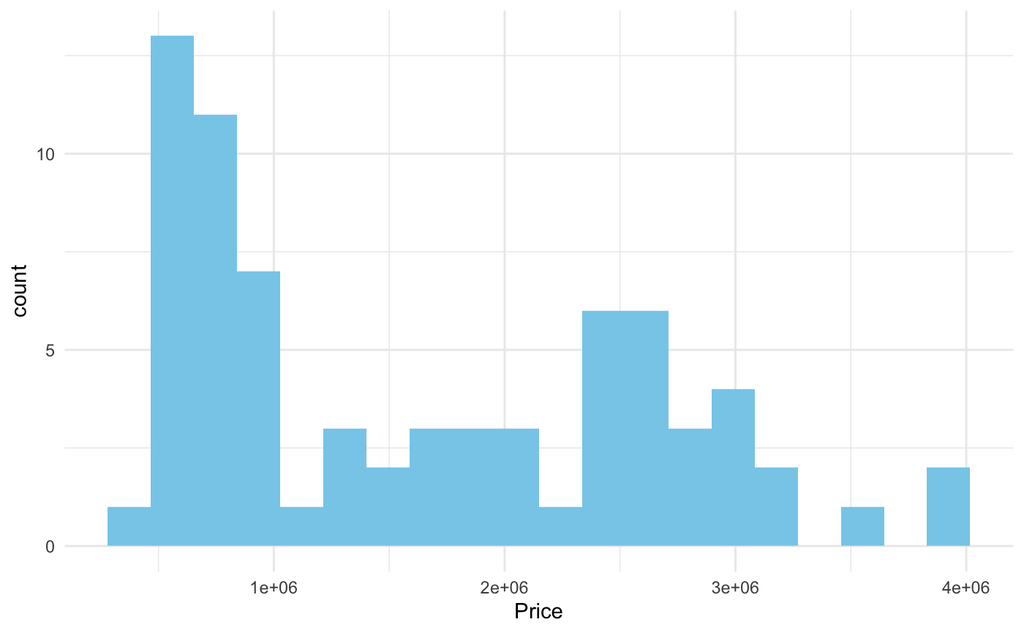

```r
# Load necessary libraries
library(ggplot2)

# Histogram of Price
ggplot(traincars, aes(x = Price)) + geom_histogram(bins = 20, fill = "skyblue") + theme_minimal()
```

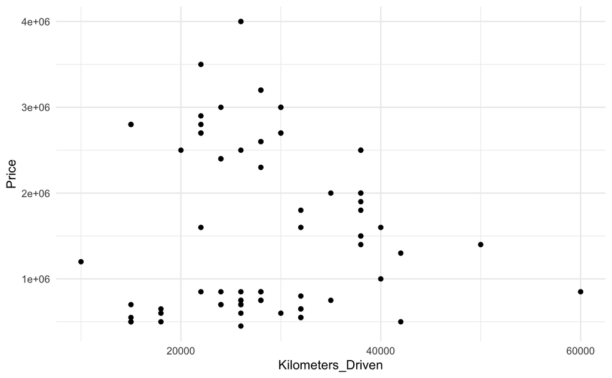

```r
# Scatter plots for numerical features vs Price
ggplot(traincars, aes(x = Kilometers_Driven, y = Price)) + geom_point() + theme_minimal()
```

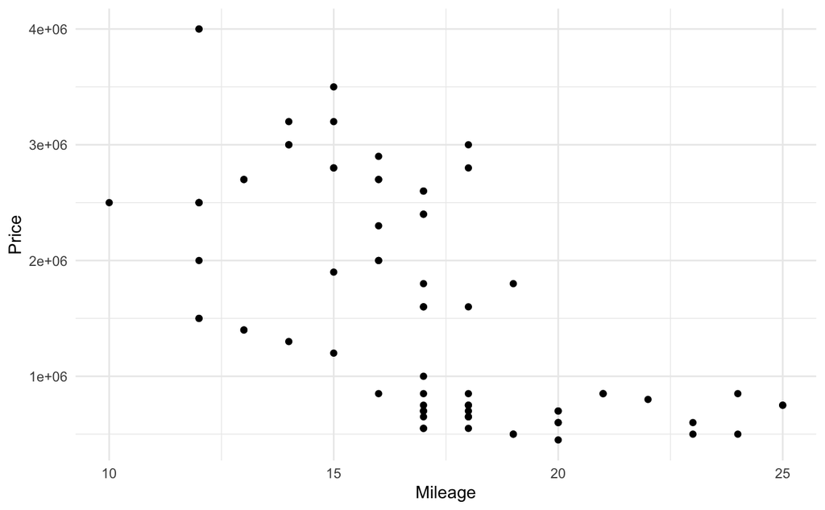

```r
ggplot(traincars, aes(x = Mileage, y = Price)) + geom_point() + theme_minimal()
```

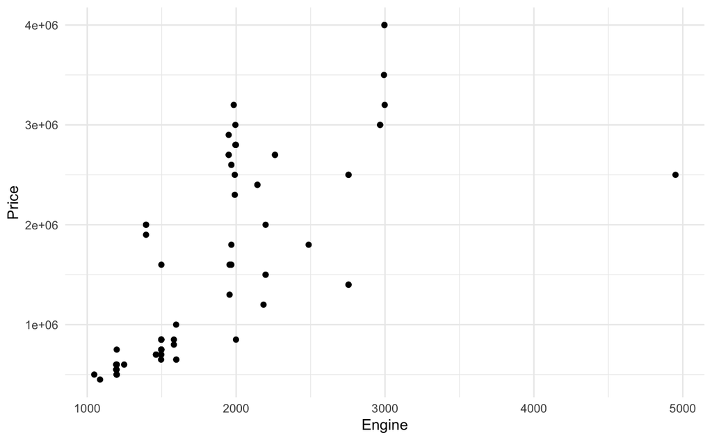

```r
ggplot(traincars, aes(x = Engine, y = Price)) + geom_point() + theme_minimal()
```

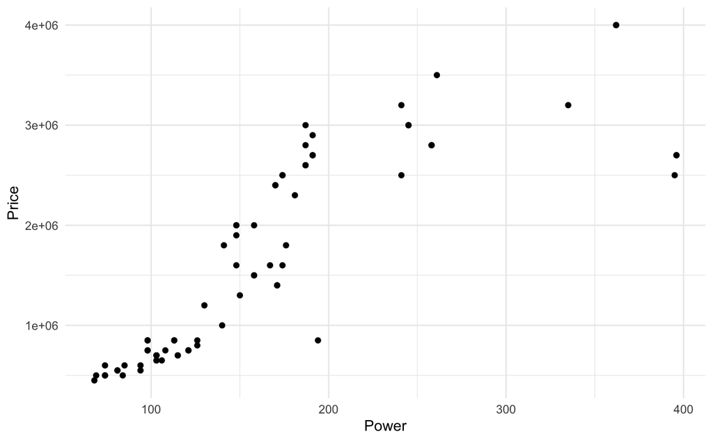

```r
ggplot(traincars, aes(x = Power, y = Price)) + geom_point() + theme_minimal()
```

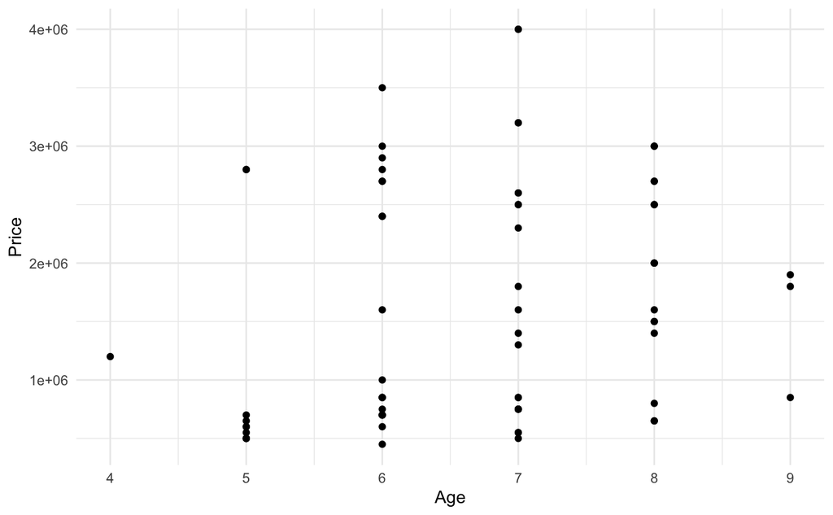

```r
ggplot(traincars, aes(x = Age, y = Price)) + geom_point() + theme_minimal()
```

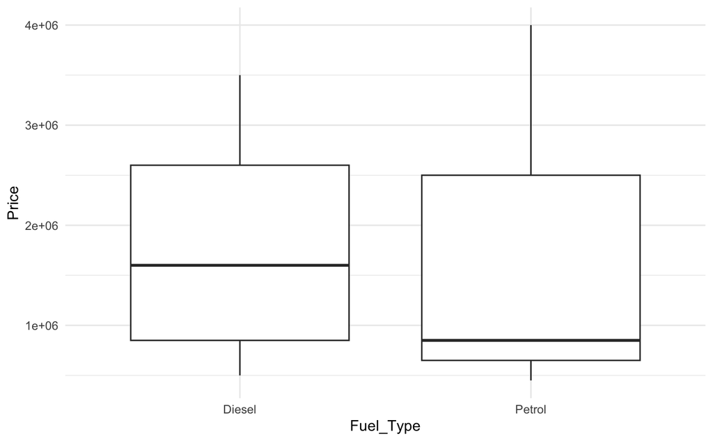

```r
# Boxplots for categorical features
ggplot(traincars, aes(x = Fuel_Type, y = Price)) + geom_boxplot() + theme_minimal()
```

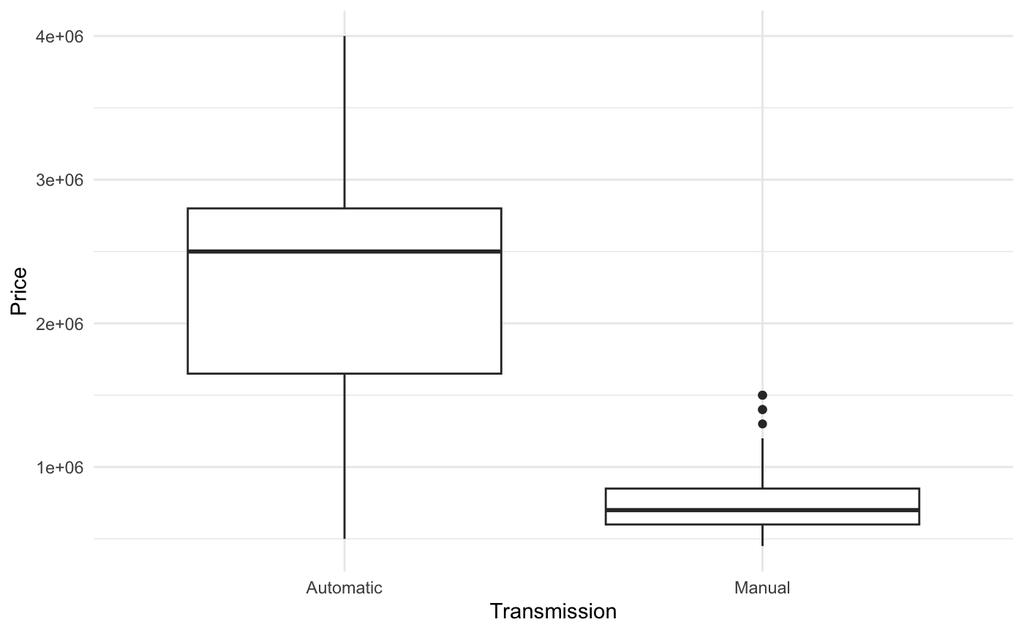

```r
ggplot(traincars, aes(x = Transmission, y = Price)) + geom_boxplot() + theme_minimal()
```